# STAT 853 - Final Project

Barinder Thind - 301193363

March 24, 2019

This is the R Markdown file containing all my code for the STAT 853 final project. I will organize this code as follows:

SECTION 0

```r
library(reshape)
library(ggplot2)
library(dplyr)
library(grid)
library(pracma)
library(rmutil)
library(deSolve)
library(RJSONIO)
library(keras)
library(abind)
library(kohonen)
library(tidyr)
library(tensorflow)
```

SECTION I

First, I present code on Euler’s method:

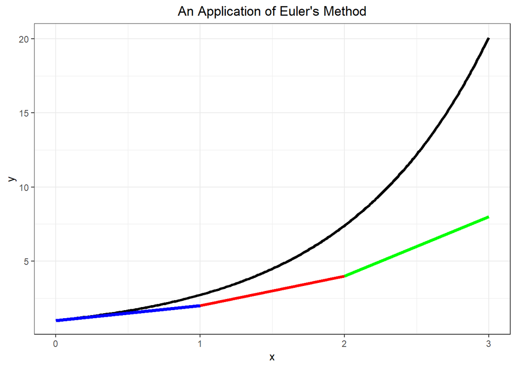

```r
### Euler Method Example

## Making exact plot
x = seq(0, 3, 0.01)
e_df = data.frame(x = x, y = exp(x))

## Getting iterations
x_1 = seq(0, 1, 0.01)
x_2 = seq(1.0, 2, 0.01)
x_3 = seq(2.0, 3, 0.01)
y_0 = 1; y_1 = y_0 + 1; y_2 = y_1 + 2; y_3 = y_2 + 4;
iter1 = data.frame(x = 1, y_1 = y_1)
iter2 = data.frame(x = 2, y_2 = y_2)
iter3 = data.frame(x = 3, y_3 = y_3)

## Plotting
e_df %>%
  ggplot(aes(x = x, y = y)) +
  geom_line(size = 1.25) +
  geom_segment(data = iter1,
            aes(x = 0, y = 1, xend = x, yend = y_1),
            color = "blue",
            size = 1.5) +
  geom_segment(data = iter2,
               aes(x = 1, y = y_1, xend = x, yend = y_2),
               color = "red",
               size = 1.5) +
  geom_segment(data = iter3,
               aes(x = 2, y = y_2, xend = x, yend = y_3),
               color = "green",
               size = 1.5) +
  ggtitle("An Application of Euler's Method") +
  theme_bw() +
  theme(plot.title = element_text(hjust = 0.5))
```

Next, I present the code for the solutions curves:

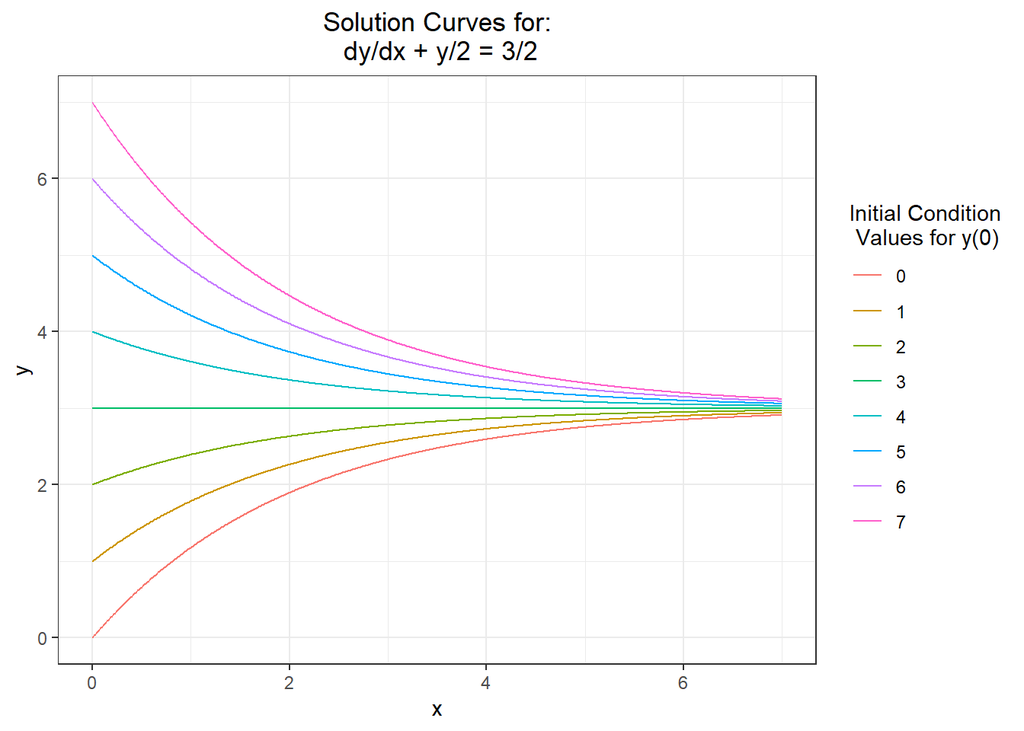

```r
### Solutions Curves

# x Values
x = seq(0, 7, 0.01)

# Solution function for ODE
y = function(y_o) {return(3 + (y_o - 3)*exp(-x/2))}

# Creating data frame
solution_curves = data.frame(cbind(x, apply(as.matrix(0:7), 1, FUN = y)))
reshaped_solutions <- melt(solution_curves ,  id.vars = 'x')

# Plotting
reshaped_solutions %>%
  ggplot(aes(x, value)) +
  geom_line(aes(colour = variable)) +
  ggtitle("Solution Curves for:\n dy/dx + y/2 = 3/2") +
  theme_bw() +
  theme(plot.title = element_text(hjust = 0.5)) +
  xlab("x") +
  ylab("y") +
  labs(color = "Initial Condition\n Values for y(0)") +
  scale_color_hue(labels = as.character(0:7))
```

Next, I present the code for a runge-kutta comparison. This was part of tests done to find good ODE solvers for the Neural ODE section. The plot here wasn’t given in the final report but was relevant to the thought process:

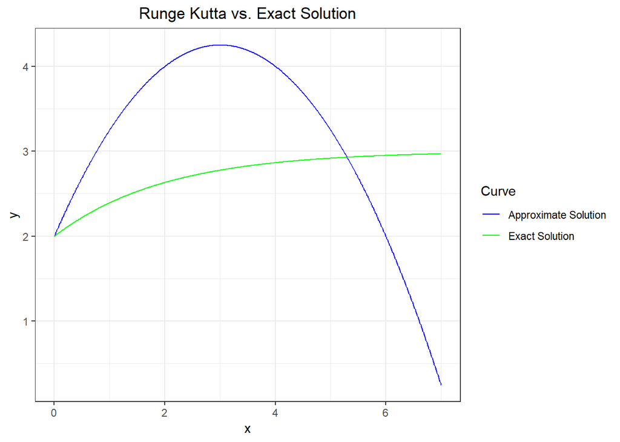

```r
### Solving using Runge Kutta
## By package

# Defining ODE
ode <- function(x, y){
  return((1/2)*(3 - y))
}

# Defining initial condition
y_initial <-  2

# x values
x = seq(0, 7, 0.01)

# Solution function for ODE
y = function(y_o) {return(3 + (y_o - 3)*exp(-x/2))}

# Creating data frame
solution_curves = data.frame(cbind(x, apply(as.matrix(0:7), 1, FUN = y)))

# Running runge-kutta
runge_solution <- runge.kutta(ode, y_initial, x)

# Making data frame for comparison
comp_df <- melt(data.frame(x = x, approx_sol = runge_solution, exact_sol = solution_curves$V4),
                id.vars = "x")

# Plotting exact vs. approx
comp_df %>%
  ggplot(aes(x, value)) +
  geom_line(aes(colour = variable)) +
  ggtitle("Runge Kutta vs. Exact Solution") +
  theme_bw() +
  theme(plot.title = element_text(hjust = 0.5)) +
  xlab("x") +
  ylab("y") +
  labs(color = "Curve") +
  scale_color_manual(labels = c("Approximate Solution", "Exact Solution"),
                    values = c("Blue", "Green"))
```

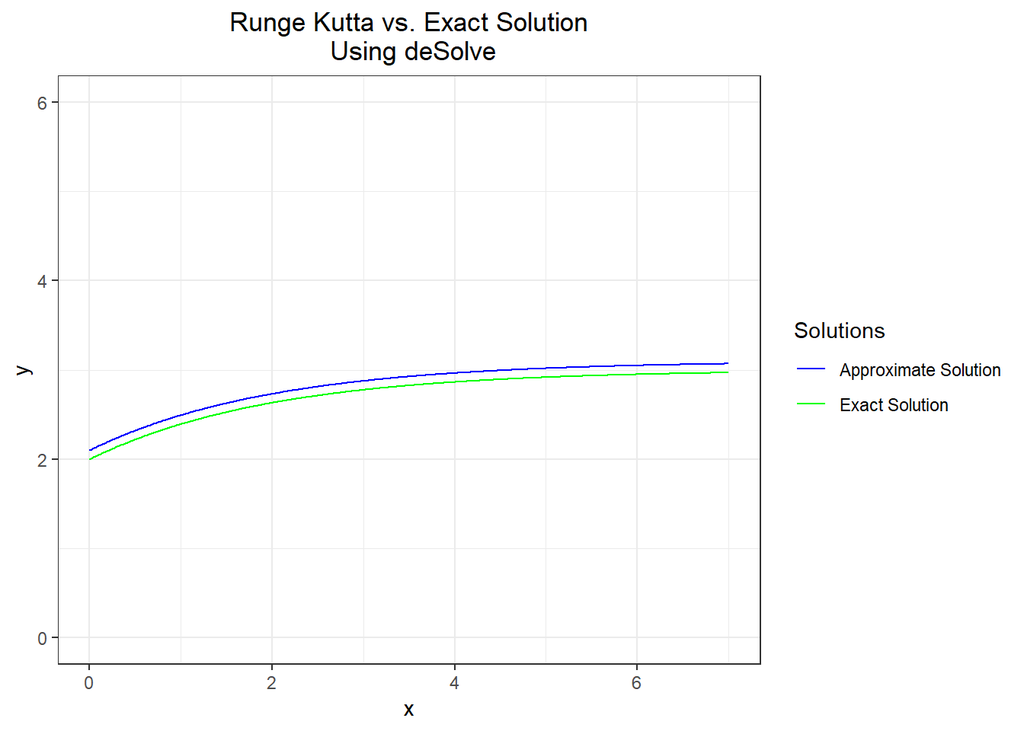

```r
# Using alternative function

# Defining ODE again
ode_rk4 <- function(t, y, parms){
  dydx = (a)*(b - y)
  return(list(dydx))
}

# Defining parameters
x = seq(0, 7, 0.01)
a = 1/2
b = 3
parms = c(a = a, b = b)
y_initial = c(y_initial = 2)

# Running from deSolve package
runge_solution_rk4 <- rk4(y_initial, x, ode_rk4, parms)

# Creating data frame
rk4_df <- melt(data.frame(x = x,
                          approx_sol = runge_solution_rk4[,2] + 0.1,
                          exact_sol = solution_curves$V4),
                id.vars = "x")

# Plotting
rk4_df %>%
  ggplot(aes(x, value)) +
  geom_line(aes(colour = variable)) +
  ggtitle("Runge Kutta vs. Exact Solution\n Using deSolve") +
  theme_bw() +
  theme(plot.title = element_text(hjust = 0.5)) +
  xlab("x") +
  ylab("y") +
  ylim(c(0, 6)) +
  labs(color = "Solutions") +
  scale_color_manual(labels = c("Approximate Solution", "Exact Solution"),
                     values = c("Blue", "Green"))
```

Next, I present code for vector fields; again, these serve as a valuable tool in ultimately understanding Neural ODE’s.

[figure not shown]

```r
# Defining ODE; dy/dx = x - y
ode <- function(x, y){
  return(x - y)
}

# Evaluating slopes
combo_values <- expand.grid(list(x = seq(-4, 4, 0.1), y = seq(-4, 4, 0.1)))

# Running function through these combinations
combo_values$ODEvalue <- ode(combo_values$x, combo_values$y)

# Plotting vector field using ggplot
combo_values %>%
  ggplot(aes(x = x, y = y)) +
  theme_bw() +
  geom_segment(aes(x = x, y = y, xend = x + 0.1,
               yend = y + ODEvalue),
               arrow = arrow(length = unit(0.2,"cm")),
               size = 1)
```

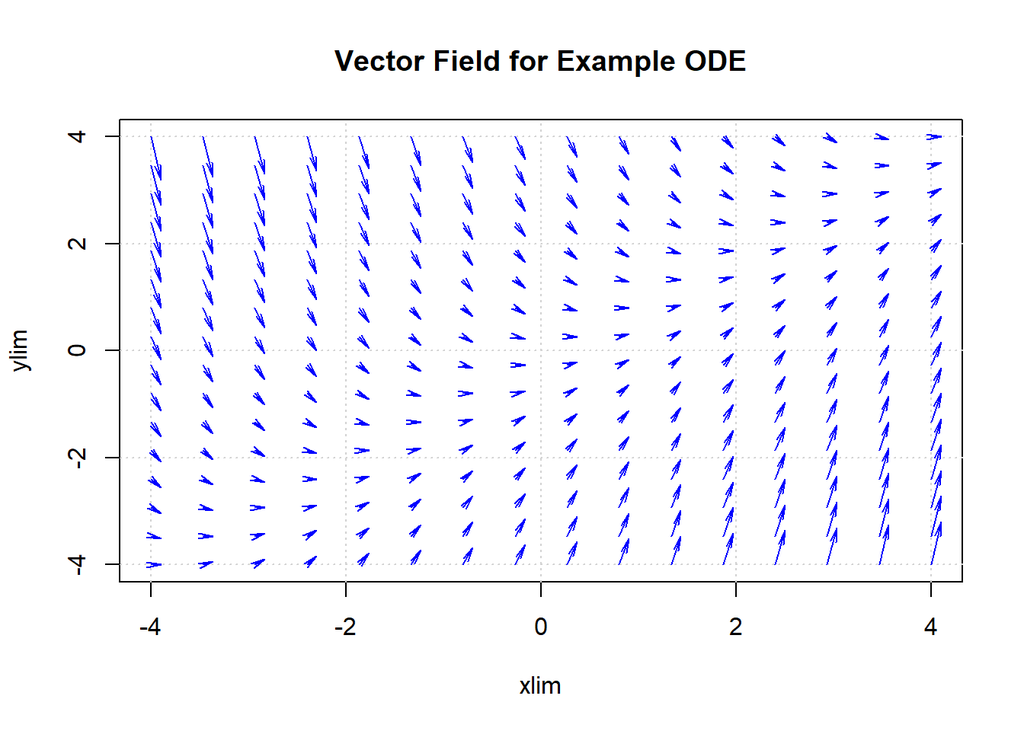

```r
# Plotting in another way
xx <- c(-4, 4)
yy <- c(-4, 4)
vectorfield(ode, xx, yy, scale = 0.1, col = "blue")
title(main = "Vector Field for Example ODE")
```

```r
# Plotting solutions
#for (xs in seq(-4, 4, by = 0.25)) {
#  sol <- rk4(ode, -4, 4, xs, 100)
#  lines(sol$x, sol$y, col="darkgreen")
#}
```

Next, I present code for phase portraits. These were useful for the interpretation of some Neural ODE plots.

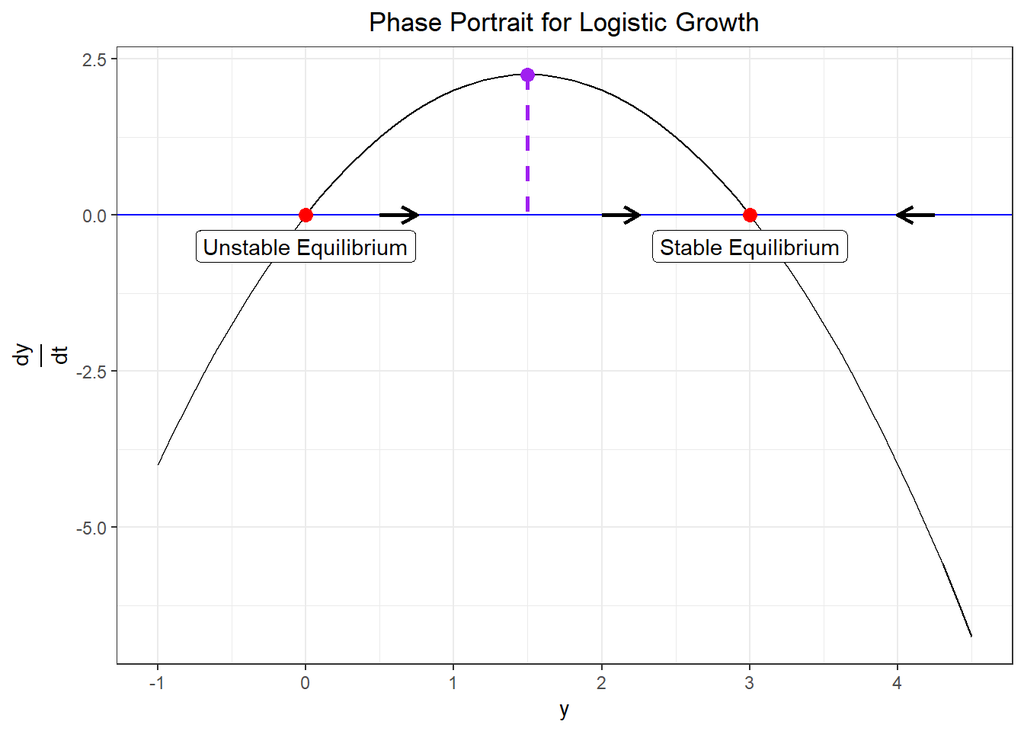

```r
# Defining ODE; dy/dx = x - y
ode <- function(x, y, a, r){
  K = r/a
  return(r*(1 - (y/K))*y)
}

# Generating data
y = seq(-1, 4.5, 0.1)
dy = ode(0, y, 1, 3)
phase_data = data.frame(y, dy)

# Plotting
phase_data %>%
  ggplot(aes(x = y, y = dy)) +
  geom_line() +
  theme_bw() +
  labs(x = "y", y = bquote(frac(dy, dt)), title = "Phase Portrait for Logistic Growth") +
  theme(plot.title = element_text(hjust = 0.5)) +
  geom_hline(yintercept = 0, color = "Blue") +
  geom_segment(aes(x = y[which.max(dy)],
                   y = dy[which.max(dy)],
                   xend = y[which.max(dy)],
                   yend = 0),
             color = "purple",
             linetype="dashed",
             size = 1) +
  geom_point(data = data.frame(x = y[which(dy == 0)], y = dy[which(dy == 0)]),
             aes(x = x, y = y),
             color = "red",
             size = 3) +
  geom_point(aes(x = y[which.max(dy)], y = dy[which.max(dy)]),
             color = "purple",
             size = 3) +
  geom_segment(data = data.frame(a = c(0.5, 2), b = c(0, 0)),
                   aes(x = a, y = b,
                   xend = a + 0.25,
                   yend = b),
               arrow = arrow(length = unit(0.3, "cm")),
               size = 1) +
  geom_segment(data = data.frame(a = c(4), b = c(0)),
               aes(x = a + 0.25, y = b,
                   xend = a,
                   yend = b),
               arrow = arrow(length = unit(0.3, "cm")),
               size = 1) +
  geom_label(data = data.frame(x = y[which(dy == 0)],
                               y = dy[which(dy == 0)],
                               state = c("Unstable Equilibrium", "Stable Equilibrium")),
             aes(x = x, y = y, label = state),
             nudge_y = -0.5)
```

SECTION II

First, I present the code for the Neural Network from scratch. The derivates are calculated in accordance to the chain rule and under the backpropagation approach. Loss is calculated and plotted in the end along with the iterations.

The three outputs will be:

1. A preview of the data set
2. the loss at the end beginning, before training and after taining
3. A graph showcasing the error after each epoch

```r
### Setting seed
set.seed(25)

## Defining data frame
x <- rnorm(100)
y <- ifelse(x >= -0.5 & x <= 0.5, 1, 0)
gaussian_df <- sample(data.frame(rn = x, resp = y))

## Poisoning the data
#gaussian_df[sample(which(gaussian_df$resp == 1), 25),] = 0

## Looking at data set
head(gaussian_df)
```

```
##           rn resp
## 1 -0.2118336    1
## 2 -1.0415911    0
## 3 -1.1533076    0
## 4  0.3215315    1
## 5 -1.5001299    0
## 6 -0.4455333    1
```

```r
## Activation Function
sigmoid <- function(x) {
  return(1.0/(1.0 + exp(-x)))
}

## Derivative of the activation
sigmoid_deriv <- function(x) {
  return(x*(1.0 - x))
}

## Loss Function
MSE <- function(neural_net) {
  return(mean((neural_net$y - round(neural_net$output))^2))
}

## Initializing
layer_weights_1 <- c(runif(length(gaussian_df$rn)))
layer_weights_2 <- c(runif(length(gaussian_df$rn)))
layer_bias_1 <- c(runif(length(gaussian_df$rn)))
layer_bias_2 <- c(runif(length(gaussian_df$rn)))

## Setting up neural network list
neuralnet_info <- list(
  input = gaussian_df$rn,
  layer_weights_1 = layer_weights_1,
  layer_bias_1 = layer_bias_1,
  layer_weights_2 = layer_weights_2,
  layer_bias_2 = layer_bias_2,
  y = gaussian_df$resp,
  output = matrix(rep(0, 1000), ncol = 1)
)

## Forward pass
forward_pass <- function(neural_net) {

  # Layer 1 activations
  neural_net$layer1 <- c(sigmoid(neural_net$input * neural_net$layer_weights_1 +
                                   layer_bias_1))

  # Output activations
  neural_net$output <- c(sigmoid(neural_net$layer1 * neural_net$layer_weights_2 +
                                   layer_bias_2))

  return(neural_net)
}

## Backpropagation
grad_descent <- function(neural_net){

  ## Easier derivative first
  # weights closer to the output layer
  deriv_weights2 <- (
    neural_net$layer1*(2*(neural_net$y - neural_net$output)*sigmoid_deriv(neural_net$output))
  )

  ## Backpropagating to first layer
  # Applied chain rule here
  deriv_weights1 <- (2*(neural_net$y - neural_net$output)*sigmoid_deriv(neural_net$output))*neural_net$layer_weights_2
  deriv_weights1 <- deriv_weights1*sigmoid_deriv(neural_net$layer1)
  deriv_weights1 <- neural_net$input*deriv_weights1

  ## Now need to do bias derivatives
  deriv_bias2 <- 2*(neural_net$y - neural_net$output)*sigmoid_deriv(neural_net$output)
  deriv_bias1 <- 2*(neural_net$y - neural_net$output)*sigmoid_deriv(neural_net$output)*layer_weights_2*sigmoid_deriv(neural_net$layer1)

  # Weight update using derivative
  learn_rate = 1
  neural_net$layer_weights_1 <- neural_net$layer_weights_1 + learn_rate*deriv_weights1
  neural_net$layer_weights_2 <- neural_net$layer_weights_2 + learn_rate*deriv_weights2
  neural_net$layer_bias_1 <- neural_net$layer_bias_1 + learn_rate*deriv_bias1
  neural_net$layer_bias_2 <- neural_net$layer_bias_2 + learn_rate*deriv_bias2

  # Returning updated information
  return(neural_net)

}

## Error Rate after no iterations
mean(round(neuralnet_info$output) == gaussian_df$resp)
```

```
## [1] 0.64
```

```r
## Epochs
epoch_num <- 50

## Initializing loss vector
lossData <- data.frame(epoch = 1:epoch_num, MSE = rep(0, epoch_num))

## Training Neural Net
for (i in 1:epoch_num) {

  # Foreward iteration
  neuralnet_info <- forward_pass(neuralnet_info)

  # Backward iteration
  neuralnet_info <- grad_descent(neuralnet_info)

  # Storing loss
  lossData$MSE[i] <- MSE(neuralnet_info)

}

## Error Rate after 50 iterations
mean(round(neuralnet_info$output) == gaussian_df$resp)
```

```
## [1] 0.99
```

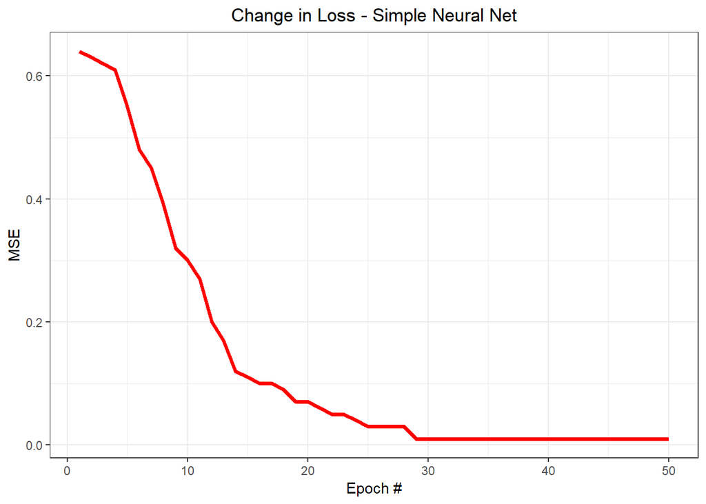

```r
## Plotting Loss
lossData %>%
  ggplot(aes(x = epoch, y = MSE)) +
  geom_line(size = 1.25, color = "red") +
  theme_bw() +
  labs(x = "Epoch #", y = "MSE") +
  ggtitle("Change in Loss - Simple Neural Net") +
  theme(plot.title = element_text(hjust = 0.5))
```

```r
## Making a test set
# x <- rnorm(25)
# y <- ifelse(x >= -0.5 & x <= 0.5, 1, 0)
# gaussian_df_test <- sample(data.frame(rn = x, resp = y))

## Making Predictions on the test set

# Layer 1 activations
# test_results <- NULL

# test_results$layer1 <- c(sigmoid(gaussian_df_test$rn * neuralnet_info$layer_weights_1 +
#                                 neuralnet_info$layer_bias_1))

# Output activations
# test_results$output <- c(sigmoid(test_results$layer1 * neuralnet_info$layer_weights_2 +
#                                 neuralnet_info$layer_bias_2))

# Predictions
## Error Rate after 50 iterations
# mean(round(test_results$output) == gaussian_df_test$resp)
```

```r
### Final NN Code Using Iceberg Dataset

## Setting seed
set.seed(1)

## Reading in dataset

# Iceberg data
train = fromJSON("train.json")

# Getting relevant information
x <- train %>%
  lapply(function(x){c(x$band_1, x$band_2)}) %>%
  unlist %>%
  array(dim=c(75, 75, 1604)) %>%
  aperm(c(3, 1, 2))

# Values for Output
y <- classvec2classmat(unlist(lapply(train, function(x) {x$is_iceberg})))
```

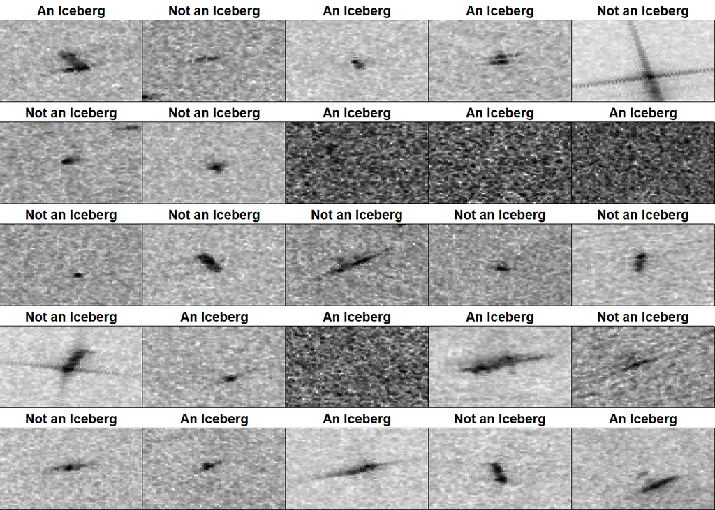

```r
# Training Set list
nums <- sample(1:1604, 1300)

# Organizing
train_iceberg <- x[nums, , ]
train_truth <- y[nums, 2]
test_iceberg <- x[-nums, , ]
test_truth <- y[-nums, 2]

# Class Names
iceberg_name <- c("Not an Iceberg", "An Iceberg")

## Need to scale data
train_iceberg <- train_iceberg/max(abs(train_iceberg))
test_iceberg <- test_iceberg/max(abs(train_iceberg))

## Looking at the first 25 images
par(mfcol=c(5,5))
par(mar=c(0, 0, 1.5, 0), xaxs='i', yaxs='i')
for (i in 1:25) {
  img <- train_iceberg[i, , ]
  img <- t(apply(img, 2, rev))
  image(1:75, 1:75, img, col = gray((-44:0)/-44), xaxt = 'n', yaxt = 'n',
        main = paste(iceberg_name[train_truth[i] + 1]))
}
```

```r
#### Creating model

# Initialization
iceberg_nn <- keras_model_sequential()

# Adding Layers
iceberg_nn %>%
  layer_flatten(input_shape = c(75, 75)) %>% # Turning image into 784 input variables
  layer_dense(units = 128, activation = 'relu') %>% # 128 neurons with relu activation, HL1
  layer_dense(units = 128, activation = 'relu') %>% # 128 neurons with relu activation, HL2
  layer_dense(units = 128, activation = 'relu') %>% # 128 neurons with relu activation, HL3
  layer_dense(units = 128, activation = 'relu') %>% # 128 neurons with relu activation, HL4
  layer_dense(units = 1, activation = 'sigmoid') # Output layer: 1 of 10 things with softmax
# activation function

## Densely connected means FULLY-CONNECTED (EACH NEURON IS INVOLVED IN THE CALCULATION OF
# EVERY SINGLE NEURON IN THE NEXT LAYER)

## Adding loss function and optimizer
iceberg_nn %>% compile(
  optimizer = "sgd", # Using stochastic gradient descent as backprop method
  loss = 'binary_crossentropy', # Using cross-entropy as loss evaluator
  metrics = c('accuracy') # Looking at accuracy
)

## Summary of model
summary(iceberg_nn)
```

```
## ___________________________________________________________________________
## Layer (type)                     Output Shape                  Param #
## ===========================================================================
## flatten (Flatten)                (None, 5625)                  0
## ___________________________________________________________________________
## dense (Dense)                    (None, 128)                   720128
## ___________________________________________________________________________
## dense_1 (Dense)                  (None, 128)                   16512
## ___________________________________________________________________________
## dense_2 (Dense)                  (None, 128)                   16512
## ___________________________________________________________________________
## dense_3 (Dense)                  (None, 128)                   16512
## ___________________________________________________________________________
## dense_4 (Dense)                  (None, 1)                     129
## ===========================================================================
## Total params: 769,793
## Trainable params: 769,793
## Non-trainable params: 0
## ___________________________________________________________________________
```

```r
## Fitting the model
iceberg_nn %>% fit(train_iceberg, train_truth, epochs = 10)

## Seeing the accuracy
score <- iceberg_nn %>% evaluate(test_iceberg, test_truth)
# Alternative: predictions_nn <-  mean(round(predict(iceberg_nn, test_iceberg)) == test_truth)
paste("Test Accuracy (NN):", score$acc)
```

```
## [1] "Test Accuracy (NN): 0.51973682641983"
```

SECTION III

In this section, I switch focus to residual neural networks. I use this approach in the context of convolutional neural networks. Note that the data set needs to be pre-processed in a slightly different way here and so, this adds a bit to the computation time.

```r
# Getting relevant information
x = train %>% lapply(function(x){
  c(x$band_1,
    x$band_2,
    apply(cbind(x$band_1,x$band_2), 1, mean))}) %>%
  unlist %>%
  array(dim=c(75,75,3,1604)) %>%
  aperm(c(4,1,2,3))

# Values for Output
y <- classvec2classmat(unlist(lapply (train, function(x) {x$is_iceberg})))

# Training Set list
nums <- sample(1:1604, 1300)

# Organizing
train_iceberg <- x[nums, , , ]
train_truth <- y[nums, ]
test_iceberg <- x[-nums, , , ]
test_truth <- y[-nums, ]

## Prepare model
kernel_size = c(5,5)
input_img = layer_input(shape = c(75, 75, 3), name="img")

## Normalizing data
input_img_norm = input_img %>%
  layer_batch_normalization(momentum = 0.99)

## input CNN
input_CNN = input_img_norm %>%
  layer_conv_2d(32, kernel_size = kernel_size, padding = "same") %>%
  layer_batch_normalization(momentum = 0.99) %>%
  layer_activation_elu() %>%
  layer_max_pooling_2d(c(2,2)) %>%
  layer_dropout(0.25) %>%
  layer_conv_2d(64, kernel_size = kernel_size,padding = "same") %>%
  layer_batch_normalization(momentum = 0.99) %>%
  layer_activation_elu() %>%
  layer_max_pooling_2d(c(2,2)) %>%
  layer_dropout(0.25)

## first residual layer
input_CNN_residual = input_CNN %>%
  layer_batch_normalization(momentum = 0.99) %>%
  layer_conv_2d(128, kernel_size = kernel_size, padding = "same") %>%
  layer_batch_normalization(momentum = 0.99) %>%
  layer_activation_elu() %>%
  layer_dropout(0.25) %>%
  layer_conv_2d(64, kernel_size = kernel_size, padding = "same") %>%
  layer_batch_normalization(momentum = 0.99) %>%
  layer_activation_elu()

# Here is the pass where the layers are put together with the previous activation
input_CNN_residual = layer_add(list(input_CNN_residual,input_CNN))

## second residual layer
input_CNN_residual = input_CNN_residual %>%
  layer_batch_normalization(momentum = 0.99) %>%
  layer_conv_2d(128, kernel_size = kernel_size,padding = "same") %>%
  layer_batch_normalization(momentum = 0.99) %>%
  layer_activation_elu() %>%
  layer_dropout(0.25) %>%
  layer_conv_2d(64, kernel_size = kernel_size,padding = "same") %>%
  layer_batch_normalization(momentum = 0.99) %>%
  layer_activation_elu()

# Here is the pass where the layers are put together with the previous activation
input_CNN_residual = layer_add(list(input_CNN_residual,input_CNN))

## final CNN
top_CNN = input_CNN_residual %>%
  layer_conv_2d(128, kernel_size = kernel_size,padding = "same") %>%
  layer_batch_normalization(momentum = 0.99) %>%
  layer_activation_elu() %>%
  layer_max_pooling_2d(c(2,2)) %>%
  layer_conv_2d(256, kernel_size = kernel_size,padding = "same") %>%
  layer_batch_normalization(momentum = 0.99) %>%
  layer_activation_elu() %>%
  layer_dropout(0.25) %>%
  layer_max_pooling_2d(c(2,2)) %>%
  layer_conv_2d(512, kernel_size = kernel_size,padding = "same") %>%
  layer_batch_normalization(momentum = 0.99) %>%
  layer_activation_elu() %>%
  layer_dropout(0.25) %>%
  layer_max_pooling_2d(c(2,2)) %>%
  layer_global_max_pooling_2d()

## Output layer
outputs = top_CNN %>%
  layer_dense(512,activation = NULL) %>%
  layer_batch_normalization(momentum = 0.99) %>%
  layer_activation_elu() %>%
  layer_dropout(0.5) %>%
  layer_dense(256,activation = NULL) %>%
  layer_batch_normalization(momentum = 0.99) %>%
  layer_activation_elu() %>%
  layer_dropout(0.5) %>%
  layer_dense(2,activation = "softmax") ## not sure using softmax is the right thing to do...

## Setting up model
model_resNN <- keras_model(inputs = list(input_img), outputs = list(outputs))

## Setting up functions for model evaluation and passes
model_resNN %>% compile(optimizer = optimizer_adam(lr = 0.001),
                  loss="binary_crossentropy",
                  metrics = c("accuracy"))

## Model set up summary
summary(model_resNN)
```

```
## ___________________________________________________________________________
## Layer (type)            Output Shape     Param #  Connected to
## ===========================================================================
## img (InputLayer)        (None, 75, 75, 3 0
## ___________________________________________________________________________
## batch_normalization_v1  (None, 75, 75, 3 12       img[0][0]
## ___________________________________________________________________________
## conv2d (Conv2D)         (None, 75, 75, 3 2432     batch_normalization_v1[0]
## ___________________________________________________________________________
## batch_normalization_v1_ (None, 75, 75, 3 128      conv2d[0][0]
## ___________________________________________________________________________
## elu (ELU)               (None, 75, 75, 3 0        batch_normalization_v1_1[
## ___________________________________________________________________________
## max_pooling2d (MaxPooli (None, 37, 37, 3 0        elu[0][0]
## ___________________________________________________________________________
## dropout (Dropout)       (None, 37, 37, 3 0        max_pooling2d[0][0]
## ___________________________________________________________________________
## conv2d_1 (Conv2D)       (None, 37, 37, 6 51264    dropout[0][0]
## ___________________________________________________________________________
## batch_normalization_v1_ (None, 37, 37, 6 256      conv2d_1[0][0]
## ___________________________________________________________________________
## elu_1 (ELU)             (None, 37, 37, 6 0        batch_normalization_v1_2[
## ___________________________________________________________________________
## max_pooling2d_1 (MaxPoo (None, 18, 18, 6 0        elu_1[0][0]
## ___________________________________________________________________________
## dropout_1 (Dropout)     (None, 18, 18, 6 0        max_pooling2d_1[0][0]
## ___________________________________________________________________________
## batch_normalization_v1_ (None, 18, 18, 6 256      dropout_1[0][0]
## ___________________________________________________________________________
## conv2d_2 (Conv2D)       (None, 18, 18, 1 204928   batch_normalization_v1_3[
## ___________________________________________________________________________
## batch_normalization_v1_ (None, 18, 18, 1 512      conv2d_2[0][0]
## ___________________________________________________________________________
## elu_2 (ELU)             (None, 18, 18, 1 0        batch_normalization_v1_4[
## ___________________________________________________________________________
## dropout_2 (Dropout)     (None, 18, 18, 1 0        elu_2[0][0]
## ___________________________________________________________________________
## conv2d_3 (Conv2D)       (None, 18, 18, 6 204864   dropout_2[0][0]
## ___________________________________________________________________________
## batch_normalization_v1_ (None, 18, 18, 6 256      conv2d_3[0][0]
```

[output cut: 62 more lines]

```
## ___________________________________________________________________________
## dense_6 (Dense)         (None, 256)      131328   dropout_6[0][0]
## ___________________________________________________________________________
## batch_normalization_v1_ (None, 256)      1024     dense_6[0][0]
## ___________________________________________________________________________
## elu_10 (ELU)            (None, 256)      0        batch_normalization_v1_13
## ___________________________________________________________________________
## dropout_7 (Dropout)     (None, 256)      0        elu_10[0][0]
## ___________________________________________________________________________
## dense_7 (Dense)         (None, 2)        514      dropout_7[0][0]
## ===========================================================================
## Total params: 5,578,574
## Trainable params: 5,574,024
## Non-trainable params: 4,550
## ___________________________________________________________________________
```

```r
## Fitting the model
model_resNN %>% fit(train_iceberg, train_truth, epochs = 10)

## Trying on test data
predictions_resnet <-  mean(round(predict(model_resNN, test_iceberg))[,2] == test_truth[,2])
paste("Test Accuracy (ResNN):", predictions_resnet)
```

```
## [1] "Test Accuracy (ResNN): 0.865131578947368"
```

Here, middle convolutional layers are residual blocks.

SECTION IV

In this section, I begin working on Neural ODE’s. I will go chunk by chunk and explain it in as much detail as possible. I will write pseudocode for the code chunks not yet completed. I will use lower case roman letters to distinguish between sections.

Before doing any of that however, I will use the R Package Reticulate to demonstrate a python implementation and plot the loss results. This is a long chunk of code because Reticulate requires all code be in a single chunk - it won’t hold memory from one chunk to another. I try my best to comment each section. Mind you, this is essentially source code for the original paper (i.e. it’s not written by me - essentially, it’s like rewriting the source code for a ggplot or dplyr package or something like that). I do my best to comment every section in the code in as much detail as possible. I always pull out the final results and code them in R. The — dashed lines encompass this python section. I will include a separate document hoping to explain some errors if you run into them.

EDIT: THIS CODE IS IN A SEPARATE RMD FILE. I was running into GPU issues trying to compile this along with the other code (keras in R). I was able to compile the code contained within the dashed lines in a separate .rmd file. I will be emailing both HTML files and both .rmd files!

```r
library(reticulate)
use_virtualenv("r-reticulate")
py_available(TRUE)
```

Here we go with the python code.

```python
# Here, first loaded are some dependencies
# These libraries range from the deep learning architectures
# required for the neural ODE to work (such as torch) and
# more essential libraries like math and numpy for
# ODE and array operations; the matplotlab library is for graphics
# purposes and the pandas library is for data frame manipulation
# Cude allows access to GPU use

##############
import math
import numpy as np
from IPython.display import clear_output
from tqdm import tqdm_notebook as tqdm

import matplotlib as mpl
import matplotlib.pyplot as plt
import seaborn as sns
sns.color_palette("bright")
import matplotlib as mpl
import matplotlib.cm as cm
import pandas as pd

import torch
from torch import Tensor
from torch import nn
from torch.nn  import functional as F
from torch.autograd import Variable

import torchvision

use_cuda = torch.cuda.is_available()
##############

# Next, here is the general ODE solve function we will use in the
# forward pass later on. Euler's method is used here because it is
# easy to implement - the step size is 0.05 (thus separating it
# from ResNets)

##############
def ode_solve(z0, t0, t1, f):
    """
    Simplest Euler ODE initial value solver
    """
    h_max = 0.05
    n_steps = math.ceil((abs(t1 - t0)/h_max).max().item())

    h = (t1 - t0)/n_steps
    t = t0
    z = z0

    for i_step in range(n_steps):
        z = z + h * f(z, t)
        t = t + h
    return z
##############

# This function computes the derivatives required in the
# forward pass and reduces the number of parameters with the
# flatten parameters function. Flattening lowers the "denseness"
# of your model layer to layer - more on this in the final report
class ODEF(nn.Module):
    def forward_with_grad(self, z, t, grad_outputs):
        """Compute f and a df/dz, a df/dp, a df/dt"""
        batch_size = z.shape[0]

        out = self.forward(z, t)

        a = grad_outputs
        adfdz, adfdt, *adfdp = torch.autograd.grad(
            (out,), (z, t) + tuple(self.parameters()), grad_outputs=(a),
            allow_unused=True, retain_graph=True
        )
        # grad method automatically sums gradients for batch items, we have to expand them back
        if adfdp is not None:
            adfdp = torch.cat([p_grad.flatten() for p_grad in adfdp]).unsqueeze(0)
            adfdp = adfdp.expand(batch_size, -1) / batch_size
        if adfdt is not None:
            adfdt = adfdt.expand(batch_size, 1) / batch_size
        return out, adfdz, adfdt, adfdp

    def flatten_parameters(self):
        p_shapes = []
        flat_parameters = []
        for p in self.parameters():
            p_shapes.append(p.size())
            flat_parameters.append(p.flatten())
        return torch.cat(flat_parameters)
##############

# Here, this is the adjoint call of the method. Remember, this is used
# in the backward pass and this is defined here as well along with the
# augmented dynamics. Moreover, the integrals in the backward trajectory
# of the backpropagation process are computed over here. The exact
# mathematical details of the "augmented" state, I am still trying to
# work out. I have more in the final report but for now, take this to be
# the funky source code that it is!

##############
class ODEAdjoint(torch.autograd.Function):
    @staticmethod
    def forward(ctx, z0, t, flat_parameters, func):
        assert isinstance(func, ODEF)
        bs, *z_shape = z0.size()
        time_len = t.size(0)

        with torch.no_grad():
            z = torch.zeros(time_len, bs, *z_shape).to(z0)
            z[0] = z0
            for i_t in range(time_len - 1):
                z0 = ode_solve(z0, t[i_t], t[i_t+1], func)
                z[i_t+1] = z0

        ctx.func = func
        ctx.save_for_backward(t, z.clone(), flat_parameters)
        return z

    @staticmethod
    def backward(ctx, dLdz):
        """
        dLdz shape: time_len, batch_size, *z_shape
        """
        func = ctx.func
        t, z, flat_parameters = ctx.saved_tensors
        time_len, bs, *z_shape = z.size()
        n_dim = np.prod(z_shape)
        n_params = flat_parameters.size(0)

        # Dynamics of augmented system to be calculated backwards in time
        def augmented_dynamics(aug_z_i, t_i):
            """
            tensors here are temporal slices
            t_i - is tensor with size: bs, 1
            aug_z_i - is tensor with size: bs, n_dim*2 + n_params + 1
            """
            z_i, a = aug_z_i[:, :n_dim], aug_z_i[:, n_dim:2*n_dim]  # ignore parameters and time

            # Unflatten z and a
            z_i = z_i.view(bs, *z_shape)
            a = a.view(bs, *z_shape)
            with torch.set_grad_enabled(True):
                t_i = t_i.detach().requires_grad_(True)
                z_i = z_i.detach().requires_grad_(True)
                func_eval, adfdz, adfdt, adfdp = func.forward_with_grad(z_i, t_i, grad_outputs=a)  # bs, *z_shape
                adfdz = adfdz.to(z_i) if adfdz is not None else torch.zeros(bs, *z_shape).to(z_i)
                adfdp = adfdp.to(z_i) if adfdp is not None else torch.zeros(bs, n_params).to(z_i)
                adfdt = adfdt.to(z_i) if adfdt is not None else torch.zeros(bs, 1).to(z_i)

            # Flatten f and adfdz
            func_eval = func_eval.view(bs, n_dim)
            adfdz = adfdz.view(bs, n_dim)
            return torch.cat((func_eval, -adfdz, -adfdp, -adfdt), dim=1)

        dLdz = dLdz.view(time_len, bs, n_dim)  # flatten dLdz for convenience
        with torch.no_grad():
            ## Create placeholders for output gradients
            # Prev computed backwards adjoints to be adjusted by direct gradients
            adj_z = torch.zeros(bs, n_dim).to(dLdz)
            adj_p = torch.zeros(bs, n_params).to(dLdz)
            # In contrast to z and p we need to return gradients for all times
            adj_t = torch.zeros(time_len, bs, 1).to(dLdz)

            for i_t in range(time_len-1, 0, -1):
                z_i = z[i_t]
                t_i = t[i_t]
                f_i = func(z_i, t_i).view(bs, n_dim)
```

```python
                # Compute direct gradients
                dLdz_i = dLdz[i_t]
                dLdt_i = torch.bmm(torch.transpose(dLdz_i.unsqueeze(-1), 1, 2), f_i.unsqueeze(-1))[:, 0]

                # Adjusting adjoints with direct gradients
                adj_z += dLdz_i
                adj_t[i_t] = adj_t[i_t] - dLdt_i

                # Pack augmented variable
                aug_z = torch.cat((z_i.view(bs, n_dim), adj_z, torch.zeros(bs, n_params).to(z), adj_t[i_t]), dim=-1)

                # Solve augmented system backwards
                aug_ans = ode_solve(aug_z, t_i, t[i_t-1], augmented_dynamics)

                # Unpack solved backwards augmented system
                adj_z[:] = aug_ans[:, n_dim:2*n_dim]
                adj_p[:] += aug_ans[:, 2*n_dim:2*n_dim + n_params]
                adj_t[i_t-1] = aug_ans[:, 2*n_dim + n_params:]

                del aug_z, aug_ans

            ## Adjust 0 time adjoint with direct gradients
            # Compute direct gradients
            dLdz_0 = dLdz[0]
            dLdt_0 = torch.bmm(torch.transpose(dLdz_0.unsqueeze(-1), 1, 2), f_i.unsqueeze(-1))[:, 0]

            # Adjust adjoints
            adj_z += dLdz_0
            adj_t[0] = adj_t[0] - dLdt_0
        return adj_z.view(bs, *z_shape), adj_t, adj_p, None
##############

# Next, the code is all bunched up nicely into a class NeuralODE
# This means that the previous classes all act as dependencies for
# this class. The previous classes will be called upon when this
# code is run. There is not much else to say here other than
# this is just a compacting of everything defined thus far

##############
class NeuralODE(nn.Module):
    def __init__(self, func):
        super(NeuralODE, self).__init__()
        assert isinstance(func, ODEF)
        self.func = func

    def forward(self, z0, t=Tensor([0., 1.]), return_whole_sequence=False):
        t = t.to(z0)
        z = ODEAdjoint.apply(z0, t, self.func.flatten_parameters(), self.func)
        if return_whole_sequence:
            return z
        else:
            return z[-1]
##############

# Here, we get batch normalization (defined in the final report)

##############
def norm(dim):
    return nn.BatchNorm2d(dim)
##############

# Next, we find a convolutional block. This is similar to the ResNet
# code. It's simply defining a convolutional Neural Net

##############
def conv3x3(in_feats, out_feats, stride=1):
    return nn.Conv2d(in_feats, out_feats, kernel_size=3, stride=stride, padding=1, bias=False)
##############

# Here, the code returns some relevant information about
# the process thus far. The first line ppulls out the
# dimensions of the tensor image and the cat function
# from torch simple puts together the results

##############
def add_time(in_tensor, t):
    bs, c, w, h = in_tensor.shape
    return torch.cat((in_tensor, t.expand(bs, 1, w, h)), dim=1)
##############

# These next two classes embed a neural ODE into a convolutional
# neural network. This is analgous to the Residual blocks being embedded
# in the convolutional neural network in the ResNet Secion III. The
# options for the convolutional blocks are similar to that of the
# R keras counterparts (number of neurons, kernel sizes, Relu activation, etc)
class ConvODEF(ODEF):
    def __init__(self, dim):
        super(ConvODEF, self).__init__()
        self.conv1 = conv3x3(dim + 1, dim)
        self.norm1 = norm(dim)
        self.conv2 = conv3x3(dim + 1, dim)
        self.norm2 = norm(dim)

    def forward(self, x, t):
        xt = add_time(x, t)
        h = self.norm1(torch.relu(self.conv1(xt)))
        ht = add_time(h, t)
        dxdt = self.norm2(torch.relu(self.conv2(ht)))
        return dxdt

class ContinuousNeuralMNISTClassifier(nn.Module):
    def __init__(self, ode):
        super(ContinuousNeuralMNISTClassifier, self).__init__()
        self.downsampling = nn.Sequential(
            nn.Conv2d(1, 64, 3, 1),
            norm(64),
            nn.ReLU(inplace=True),
            nn.Conv2d(64, 64, 4, 2, 1),
            norm(64),
            nn.ReLU(inplace=True),
            nn.Conv2d(64, 64, 4, 2, 1),
        )
        self.feature = ode
        self.norm = norm(64)
        self.avg_pool = nn.AdaptiveAvgPool2d((1, 1))
        self.fc = nn.Linear(64, 10)

    def forward(self, x):
        x = self.downsampling(x)
        x = self.feature(x)
        x = self.norm(x)
        x = self.avg_pool(x)
        shape = torch.prod(torch.tensor(x.shape[1:])).item()
        x = x.view(-1, shape)
        out = self.fc(x)
        return out
################

################
func = ConvODEF(64)
ode = NeuralODE(func)
model = ContinuousNeuralMNISTClassifier(ode)
if use_cuda:
    model = model.cuda()
################

# Here, the MNIST training data is loaded and normalized
# using the prespecified mean and standard deviation. This is
# a standard pre-processing in most neural net implementations
# as can be seen in my previous implementations

################  v
img_std = 0.3081
img_mean = 0.1307

batch_size = 32
train_loader = torch.utils.data.DataLoader(
    torchvision.datasets.MNIST("data/mnist", train=True, download=True,
                             transform=torchvision.transforms.Compose([
                                 torchvision.transforms.ToTensor(),
                                 torchvision.transforms.Normalize((img_mean,), (img_std,))
                             ])
    ),
    batch_size=batch_size, shuffle=True
)

test_loader = torch.utils.data.DataLoader(
    torchvision.datasets.MNIST("data/mnist", train=False, download=True,
                             transform=torchvision.transforms.Compose([
                                 torchvision.transforms.ToTensor(),
                                 torchvision.transforms.Normalize((img_mean,), (img_std,))
                             ])
    ),
    batch_size=32, shuffle=True
)
################

# Here the optimizer is defined

################
optimizer = torch.optim.Adam(model.parameters())
################
```

```python
# Now, this is where the training is done and the functions
# previously defined are called. The train and test functions
# are for the separate outputs. The loss function is used
# here as well with the "criterion" function. This is a call to
# cross-entropy function. The loss results are ultimately
# returned in the final outputs

################
def train(epoch):
    num_items = 0
    train_losses = []

    model.train()
    criterion = nn.CrossEntropyLoss()
    print(f"Training Epoch {epoch}...")
    for batch_idx, (data, target) in tqdm(enumerate(train_loader), total=len(train_loader)):
        if use_cuda:
            data = data.cuda()
            target = target.cuda()
        optimizer.zero_grad()
        output = model(data)
        loss = criterion(output, target)
        loss.backward()
        optimizer.step()

        train_losses += [loss.item()]
        num_items += data.shape[0]
    print('Train loss: {:.5f}'.format(np.mean(train_losses)))
    return train_losses


def test():
    accuracy = 0.0
    num_items = 0

    model.eval()
    criterion = nn.CrossEntropyLoss()
    print(f"Testing...")
    with torch.no_grad():
        for batch_idx, (data, target) in tqdm(enumerate(test_loader),  total=len(test_loader)):
            if use_cuda:
                data = data.cuda()
                target = target.cuda()
            output = model(data)
            accuracy += torch.sum(torch.argmax(output, dim=1) == target).item()
            num_items += data.shape[0]
    accuracy = accuracy * 100 / num_items
    print("Test Accuracy: {:.3f}%".format(accuracy))
################

# Next, here is some initialization and the number of epochs is defined

################
n_epochs = 1
test()
train_losses = []
################

# Finally, everything above is called and run

################
for epoch in range(1, n_epochs + 1):
    train_losses += train(epoch)
    test()
################

# The loss results are pulled out in the form of a CSV (using pandas)

################
loss_data = pd.DataFrame({"loss": train_losses})
loss_data["Trained_Images"] = loss_data.index * batch_size
loss_data["Halflife_Loss"] = loss_data.loss.ewm(halflife=10).mean()
loss_data.to_csv('neural_ode_loss.csv')
################
```

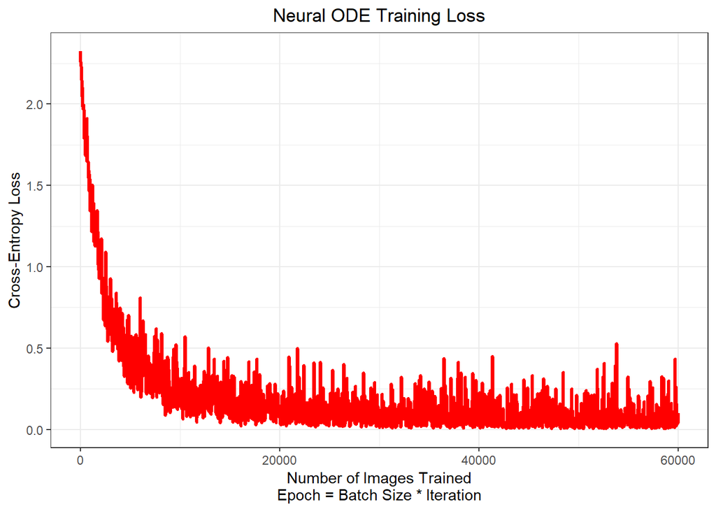

```r
# Reading in loss results from python
neuralODELoss = read.csv("neural_ode_loss.csv", header = T)

# Plotting
neuralODELoss %>%
  ggplot(aes(x = Trained_Images, y = loss)) +
  geom_line(color = "red", size = 1.1) +
  theme_bw() +
  labs(x = "Number of Images Trained\nEpoch = Batch Size * Iteration", y = "Cross-Entropy Loss") +
  ggtitle("Neural ODE Training Loss") +
  theme(plot.title = element_text(hjust = 0.5))
```

Now, here is where I begin writing functions and what not for an R implementation - THIS SECTION IS INCOMPLETE! However, what I could do is there. I will look to continue to complete these over the next little while,

SECTION IV.i - Relevant Packages

Here, I load some relevant libraries for Neural ODE’s. Note: I repeat some of the ones from before for the purpose of completeness.

```r
library(tidyverse)
library(keras)
library(tensorflow)
```

SECTION IV.ii - ODESolver

Here, I develop the “black-box” ODE solver. For simplicity purposes, I will limit myself to Euler’s method but with an adjustable step size (thus separating it from ResNets)

```r
ode_solve <- function(z0, t0, t1, f) {

  # Step Size Choice:
  h_max = 0.05
  n_steps = ceiling((abs(t1 - t0)/h_max))

  # Initializing
  h = (t1 - t0)/n_steps
  t = t0
  z = z0

  # Running algorithm
  for (i in 1:n_steps) {
    z = z + h*f(z, t)
    t = t + h
  }

  # Returning
  return(z)

}
```

Now, let’s test the function to see if it’s working correctly.

```r
# Setting up function
a <- function(z, t){
  b = z
  return(b)
}

ode_solve(1, 1, 5, a)
```

```
## [1] 49.56144
```

SECTION IV.iii - Adjoint Method

SECTION IV.iv - Augmented Dynamics

SECTION IV.v - Forward Pass

SECTION IV.vi - Backward Pass

SECTION IV.vii - Convolutional Code

In this chunk of code, I define a batch normalization function, a convolution function, a time function, and the overall Neural ODE classifier

```r
convODEF <- function(ODEF){

  # Initializing
  conv1 = layer_conv_2d()
}
```

SECTION IV.viii - Data Load In

Here, I load the MNIST Data:

```r
# First, I pull the general data sets from tensorflow
#datasets <- tf$contrib$learn$datasets

# Here, I pull specifically the mnist data
#mnist <- datasets$mnist$read_data_sets("MNIST-data", one_hot = TRUE)
```

SECTION IV.viv - Training Function

SECTION IV.x - Test Function

SECTION IV.xi - Neural ODE Run

SECTION IV.xii - Outputs/Results